# **Zadatak 1**

## Otkrili ste korelaciju između pređene kilometraže i potrošnje goriva u iznosu od 0,73. Uzimate li pređene kilometre kao feature koji ćete dalje proučavati kao mogući prediktor?

# **Zadatak 2**

## Otkrili ste korelaciju između broja kišnih dana u godini i broja prodanih stanova od 0,37. Uzimate li broj kišnih dana kao feature koji ćete dalje proučavati kao mogući prediktor?

# **Zadatak 3**

## Otkrili ste korelaciju između broja dana s poledicom i broja otkazanih letova od 0,51. Uzimate li broj dana s poledicom kao feature koji ćete dalje proučavati kao mogući prediktor?

# **Zadatak 4**

## Radite u prehrambenoj industriji i proučavate prodaju sladoleda. Vaši kolege iz tvornice su vam poslali neke parametre, nazovimo ih a, b, c, d. Slijede korelacije između tih parametara i same prodaje

### parametar a i prodaja = 0,42

### parametar b i prodaja = 0,39

### parametar c i prodaja = 0,35

### parametar d i prodaja = 0,41

## Koje parametre uzimate u razmatranje koje biste htjeli koristiti u vašim modelima?

# **Zadatak 5**

## Imate varijablu mjeseci (označeni brojevima od 1 - 12) te broj turista s korelacijom od 0,27. Uzimate li mjesece kao varijablu koju biste dalje proučavali za potrebe modela?

# **Zadatak 6**

## Imate varijablu kvadratura kupaone u hotelu i broja izleta u nacionalne parkove samih gostiju koja iznosi -0,92. Što je kupaona veća, gosti idu manje na izlete i obrnuto.

## Uzimate li kvadraturu kupaone kao možebitni feature za potrebe modela?

# **Zadatak 7**

## Imate varijablu tramvajske linije u ZG (brojevi 1 - 17) i minute kašnjenja s korelacijom od 0,16.

## Uzimate li tramvajske linije kao moguću varijablu za daljnje potrebe modela?

# **Zadatak 8**

## Objavljujete video zapise na društvenim mrežama. Prema vašim podacima postoji negativna korelacija od - 0,76 između broja komentara i duljine videa. Što je video zapis kraći, to je više komentara korisnika, vrijedi i obrnuto.

```python
import pandas as pd
import seaborn as sns
```

```python
stanovi = pd.read_excel ("opisnekretnina.xlsx")
```

```python
stanovi
```

|  | area | bedrooms | age | parking | price |
| --- | --- | --- | --- | --- | --- |
| 0 | 2300 | 2 | 10 | 2 | 510000 |
| 1 | 2600 | 2 | 20 | 1 | 530000 |
| 2 | 3000 | 2 | 15 | 2 | 565000 |
| 3 | 3200 | 3 | 18 | 1 | 580000 |
| 4 | 3300 | 3 | 11 | 2 | 660000 |
| 5 | 3600 | 4 | 30 | 3 | 500000 |
| 6 | 4000 | 4 | 8 | 1 | 760000 |
| 7 | 4100 | 5 | 8 | 2 | 810000 |
| 8 | 4200 | 4 | 27 | 1 | 590000 |
| 9 | 4300 | 6 | 12 | 3 | 830000 |

# Dataset s podacima o nekretninama, htjeli bi odrediti koje varijable utječu na cijenu stana

## Imamo varijable area. bedrooms, age, parking

# Slučaj multikolinearnosti

```python
stanovi.describe()
```

|  | area | bedrooms | age | parking | price |
| --- | --- | --- | --- | --- | --- |
| count | 10.000000 | 10.000000 | 10.000000 | 10.000000 | 10.000000 |
| mean | 3460.000000 | 3.500000 | 15.900000 | 1.800000 | 633500.000000 |
| std | 696.339636 | 1.354006 | 7.766738 | 0.788811 | 124589.325385 |
| min | 2300.000000 | 2.000000 | 8.000000 | 1.000000 | 500000.000000 |
| 25% | 3050.000000 | 2.250000 | 10.250000 | 1.000000 | 538750.000000 |
| 50% | 3450.000000 | 3.500000 | 13.500000 | 2.000000 | 585000.000000 |
| 75% | 4075.000000 | 4.000000 | 19.500000 | 2.000000 | 735000.000000 |
| max | 4300.000000 | 6.000000 | 30.000000 | 3.000000 | 830000.000000 |

```python
stanovi.corr(numeric_only = True)
```

|  | area | bedrooms | age | parking | price |
| --- | --- | --- | --- | --- | --- |
| area | 1.000000 | 0.907416 | 0.032050 | 0.165874 | 0.728604 |
| bedrooms | 0.907416 | 1.000000 | -0.079243 | 0.416125 | 0.782149 |
| age | 0.032050 | -0.079243 | 1.000000 | 0.014509 | -0.620229 |
| parking | 0.165874 | 0.416125 | 0.014509 | 1.000000 | 0.154890 |
| price | 0.728604 | 0.782149 | -0.620229 | 0.154890 | 1.000000 |

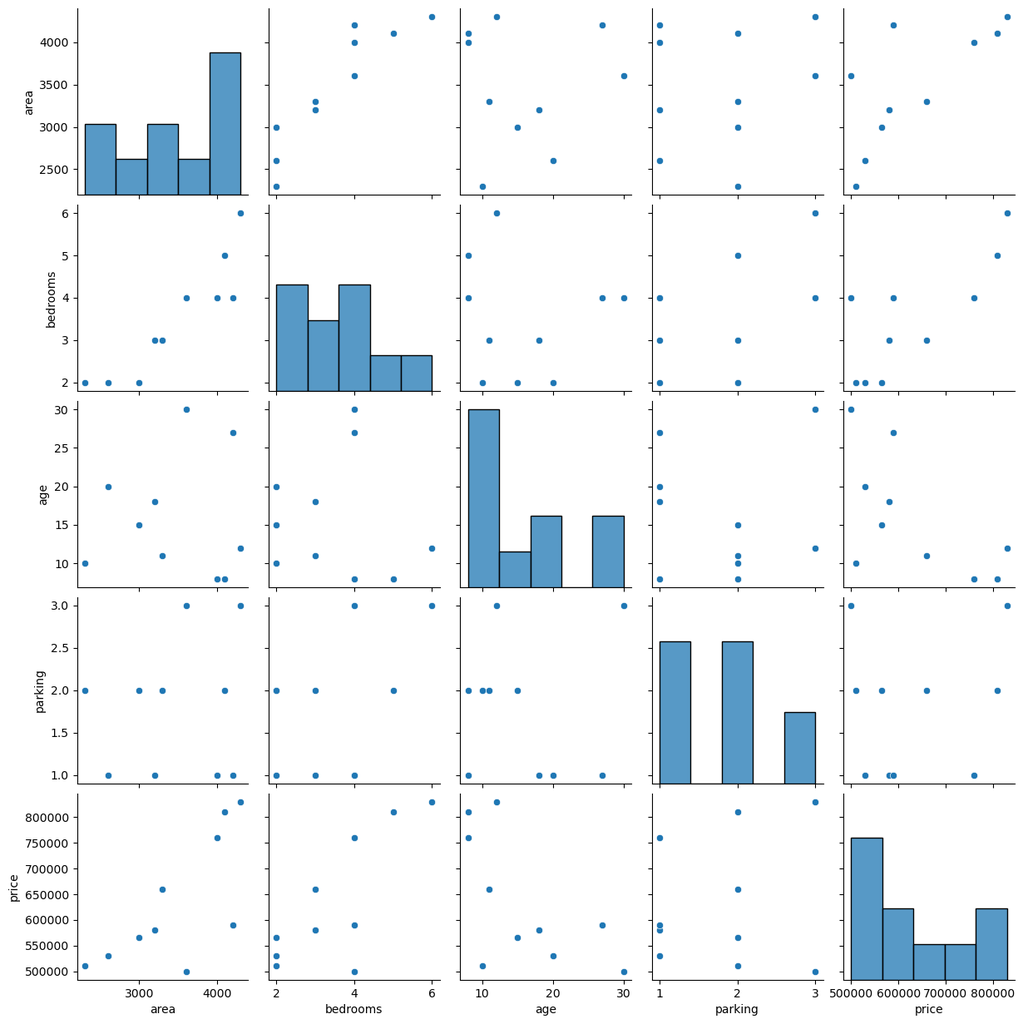

```python
sns.pairplot (stanovi)
```

# Koje varijable ostaju u analizi, a koje bismo mogli zanemariti ako želimo pručavati utjecaj na varijablu cijene stana?

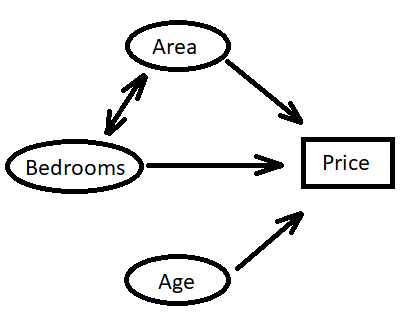

## Multikolinearnost je situacija kada imamo nekoliko nezavisnih varijabli koje međusobno koreliraju

## Podaci se de facto dupliciraju i njihovim korištenjem smanjujemo točnost modeliranja i može doći do overfittinga

## Imamo varijable Area i Bedrooms, što je veća površina stana, automatski je i veći broj soba

## Preporuka je jednu od tih varijabli onda maknuti iz analize

## Ključne varijable koje bismo koristili dalje u analizi su Area i Age

```python
stanovi_novo = stanovi[['area', 'age', 'price']]
```

```python
stanovi_novo.head()
```

|  | area | age | price |
| --- | --- | --- | --- |
| 0 | 2300 | 10 | 510000 |
| 1 | 2600 | 20 | 530000 |
| 2 | 3000 | 15 | 565000 |
| 3 | 3200 | 18 | 580000 |
| 4 | 3300 | 11 | 660000 |

# Drugi način je korištenjem metode PCA (principal component anaylsis) gdje bi kolone area i bedrooms objedinili u jednu varijablu te u sljedećem koraku maknuli kolonu parking

# **Zadatak 9**

```python
dostava = pd.read_excel ("dostava.xlsx")
```

```python
dostava
```

|  | Udaljenost | BrDostava | CijenaGoriva | Vrijeme |
| --- | --- | --- | --- | --- |
| 0 | 89 | 4 | 3.84 | 7.0 |
| 1 | 66 | 1 | 3.19 | 5.4 |
| 2 | 78 | 3 | 3.78 | 6.6 |
| 3 | 111 | 6 | 3.89 | 7.4 |
| 4 | 44 | 1 | 3.57 | 4.8 |
| 5 | 77 | 3 | 3.57 | 6.4 |
| 6 | 80 | 3 | 3.03 | 7.0 |
| 7 | 66 | 2 | 3.51 | 5.6 |
| 8 | 109 | 5 | 3.54 | 7.3 |
| 9 | 78 | 3 | 3.25 | 6.4 |

```python
kosarica = pd.read_csv ("kosarica.csv")
```

```python
kosarica.head()
```

|  | Unnamed: 0 | Potrosacka_Kosarica | Brasno | Kruh | Jaja | Mlijeko | WC_Papir |
| --- | --- | --- | --- | --- | --- | --- | --- |
| 0 | 0 | 109.934283 | 78.742935 | 75.373042 | 62.537028 | 64.349980 | 31.983760 |
| 1 | 1 | 97.234714 | 70.868222 | 71.331122 | 39.395704 | 43.456910 | 23.592977 |
| 2 | 2 | 112.953771 | 84.482896 | 87.449175 | 65.172945 | 57.438093 | 12.189833 |
| 3 | 3 | 130.460597 | 96.591428 | 100.714856 | 78.786677 | 60.607546 | 3.342008 |
| 4 | 4 | 95.316933 | 59.833506 | 65.793199 | 51.792815 | 43.313504 | 20.005043 |

```python
kosarica.corr (numeric_only = True)
```

|  | Unnamed: 0 | Potrosacka_Kosarica | Brasno | Kruh | Jaja | Mlijeko | WC_Papir |
| --- | --- | --- | --- | --- | --- | --- | --- |
| Unnamed: 0 | 1.000000 | 0.071231 | 0.061833 | 0.063742 | 0.039902 | -0.007715 | -0.052879 |
| Potrosacka_Kosarica | 0.071231 | 1.000000 | 0.939744 | 0.927381 | 0.700157 | 0.686135 | 0.008937 |
| Brasno | 0.061833 | 0.939744 | 1.000000 | 0.926725 | 0.631522 | 0.610029 | -0.004825 |
| Kruh | 0.063742 | 0.927381 | 0.926725 | 1.000000 | 0.664253 | 0.624564 | -0.012945 |
| Jaja | 0.039902 | 0.700157 | 0.631522 | 0.664253 | 1.000000 | 0.570602 | 0.005200 |
| Mlijeko | -0.007715 | 0.686135 | 0.610029 | 0.624564 | 0.570602 | 1.000000 | 0.074511 |
| WC_Papir | -0.052879 | 0.008937 | -0.004825 | -0.012945 | 0.005200 | 0.074511 | 1.000000 |